# Distribución del pago de los servicios

## 1 Tabla de ponderación del consumo:

| Habitación | Nombre | Personas | En_casa | Aparatos | Subtotal | % Días | Coef. pond. |
| --- | --- | --- | --- | --- | --- | --- | --- |
| Hab. 1 | Andresito y Kevin | 2 | 0.5 | 5.0 | 7.5 | 100.00% | 7.500 |
| Hab. 2 | Jorge | 1 | 1.0 | 4.5 | 6.5 | 100.00% | 6.500 |
| Hab. 3 | Gary | 1 | 0.0 | 1.0 | 2.0 | 33.33% | 0.667 |
| Hab. 4 | Fabian | 1 | 0.0 | 1.0 | 2.0 | 100.00% | 2.000 |
| Apt. | Luis y Andrés | 2 | 1.0 | 5.0 | 8.0 | 100.00% | 8.000 |

### Como leer la tabla de ponderación:

Las columnas **Habitación** y **Nombre** son informativas.

La columna **Personas** asigna el valor de 1 a cada individuo residente.

En la columna **En_casa** los valores corresponden a:

- 0.0 -> Trabaja fuera de casa.
- 0.5 -> Trabaja tiempo parcial fuera de casa.
- 1.0 -> Trabaja en casa.

La columna **Subtotal** es el resultado de sumar las 3 columnas anteriores.

La columna **% Días** es una aproximación porcentual al número de días que la persona ha estado habitando la casa.

La última columna, **Coef. pond.** es el resultado de multiplicar las dos columnas anteriores y representa el valor del coeficiente para realizar la ponderación del consumo.

**NOTA:** Por favor reportar cualquier cambio en los patrones de consumo para poder ajustar los cálculos, ya que esto nos afecta a todos.

## 2 Datos de la factura:

```
Para el período de abril de 2025, el valor total a pagar por la factura de energía eléctrica es de $441.550.
Este valor corresponde a un consumo de 477Kws desde el 20 de marzo de 2025 hasta el 19 de abril de 2025 (fecha de la lectura actual), y está para pagar antes del 26 de abril de 2025.
```

## 3 Gráfica de los registros de consumo tomados del contador:

**NOTA:** Los valores repetidos significan que el consumo no se tomó todos los días, sino solo al inicio y al final del lapso en que se repiten y se promedió de acuerdo al número de días de ese período.

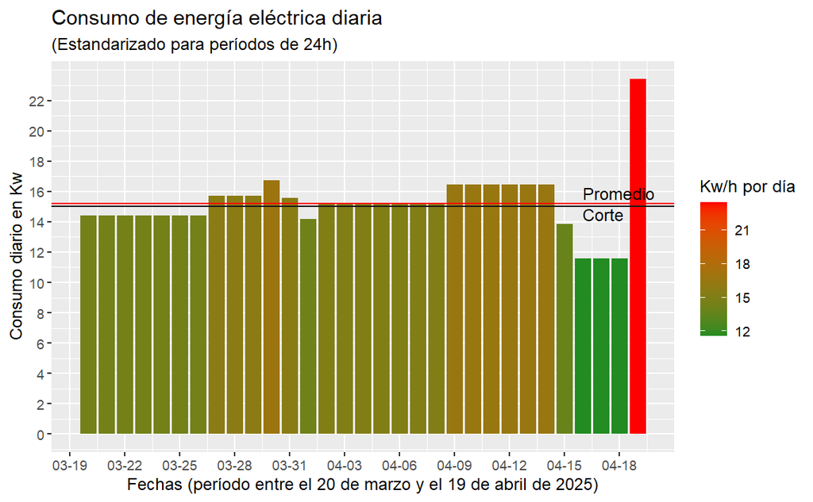

## 4 Datos para tener en cuenta:

### 4.1 Diferencia de consumo entre los datos de Air-e y los recolectados:

| Factura Air-e | Lectura Contador | Número de días | Diferencia |
| --- | --- | --- | --- |
| 477 | 471.34 | 31 días | 5.66 a favor de Air-e. |

### 4.2 Valor de corte:

El valor de corte se estableció en 15Kw por día (línea horizontal de color negro en la gráfica). Este valor se estableció teniendo en cuenta los cambios en los patrones de consumo y los promedios de meses anteriores, por esto su cercanía al valor promedio del período (línea de color rojo).

Esta línea negra representa un valor de control para observar hacia donde estamos dirigiendo el valor promedio del consumo mensual: si el promedio está por encima estamos aumentando el consumo, si está por debajo lo estamos disminuyendo.

```
Este mes hemos aumentado el promedio de consumo en 0.204 Kw por día con respecto al corte.
```

### 4.3 Valor del consumo del aire acondicionado:

Los días en que el valor del consumo diario de energía está por encima del promedio mensual (linea de color rojo) se consideran afectados por el uso del aire acondicionado. No se pueden observar los días exactos en que se prendió el aire debido al hecho de no estar tomando los valores del contador todos los días.

De acuerdo a lo anterior, el valor imputado al uso del aire acondicionado se establece a continuación:

| Consumo total | Valor Total, en $ | Consumo diario > promedio | Costo redondeado, en $ |
| --- | --- | --- | --- |
| 471.34 | 441550 | 19.08 | 17700 |

## 3.5 Total a pagar por habitación:

[output not shown]